# Redes neuronales artificiales en R

# 1. Introducción

- Aplicaremos una red neuronal a un problema de **economía de la salud**: predecir el **gasto médico anual** de un asegurado a partir de sus características.
- Es un problema de **predicción numérica** (el *outcome*, `charges`, es continuo) muy relevante para aseguradoras y para el diseño de políticas de salud.
- Ya lo abordamos con **regresión** en la sesión 3; ahora lo haremos con una **red neuronal** y compararemos. Usaremos `insurance.csv` y el paquete `neuralnet` (entrena redes sencillas en R, sin TensorFlow).

# 2. Datos

```r
insurance <- read.csv("data/insurance.csv", stringsAsFactors = FALSE)
str(insurance)
```

```
## 'data.frame':    1338 obs. of  7 variables:
##  $ age     : int  19 18 28 33 32 31 46 37 37 60 ...
##  $ sex     : chr  "female" "male" "male" "male" ...
##  $ bmi     : num  27.9 33.8 33 22.7 28.9 ...
##  $ children: int  0 1 3 0 0 0 1 3 2 0 ...
##  $ smoker  : chr  "yes" "no" "no" "no" ...
##  $ region  : chr  "southwest" "southeast" "southeast" "northwest" ...
##  $ charges : num  16885 1726 4449 21984 3867 ...
```

- Son 1.338 asegurados. El *outcome* es `charges` (gasto médico anual). Entre los predictores, `smoker` es categórico; lo convertimos a una variable numérica 0/1 (fumador = 1):

```r
insurance$smoker <- ifelse(insurance$smoker == "yes", 1, 0)
```

- Para este taller usaremos cuatro predictores numéricos: edad, índice de masa corporal, número de hijos y si es fumador. Nos quedamos con ellos y con el *outcome*:

```r
datos <- insurance[, c("age", "bmi", "children", "smoker", "charges")]
```

- En redes neuronales, por la forma de las funciones de activación, conviene **normalizar** todas las variables a un rango [0, 1]. Definimos la función y la aplicamos:

```r
normalize <- function(x) {
  return((x - min(x)) / (max(x) - min(x)))
}
datos_norm <- as.data.frame(lapply(datos, normalize))
summary(datos_norm$charges)
```

```
##    Min. 1st Qu.  Median    Mean 3rd Qu.    Max.
## 0.00000 0.05776 0.13185 0.19392 0.24770 1.00000
```

- Dividamos en entrenamiento (75%) y prueba (25%), fijando la semilla:

```r
set.seed(123)
train_idx <- sample(nrow(datos_norm), 0.75 * nrow(datos_norm))
ins_train <- datos_norm[train_idx, ]
ins_test  <- datos_norm[-train_idx, ]
```

# 3. Entrenamiento del modelo

- Usaremos `neuralnet()`, con sintaxis `m <- neuralnet(target ~ predictors, data = mydata, hidden = 1)`. Si no tienes el paquete:

```r
install.packages("neuralnet")
```

- Entrenemos una red sencilla, con una sola neurona oculta:

```r
library(neuralnet)
set.seed(123)
ins_model <- neuralnet(charges ~ age + bmi + children + smoker, data = ins_train)
```

- Visualicemos la topología de la red estimada (nodos de entrada, el nodo oculto y el de salida; en azul, los términos de sesgo):

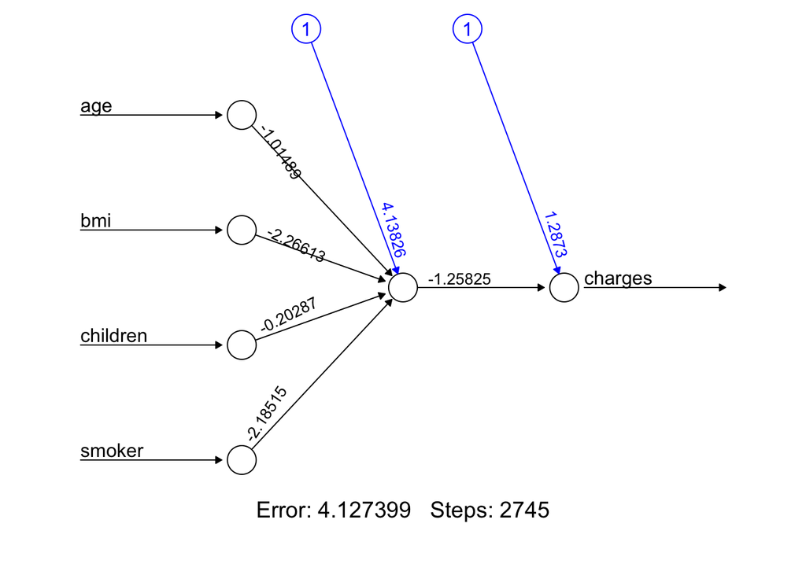

```r
plot(ins_model, rep = "best")
```

# 4. Desempeño del modelo

- Generamos predicciones sobre la base de prueba con `compute()` (usa las 4 características):

```r
model_results <- compute(ins_model, ins_test[, c("age", "bmi", "children", "smoker")])
predicted_charges <- model_results$net.result
```

- Como la predicción es **numérica**, medimos qué tan cerca está de lo observado con la **correlación**:

```r
cor(predicted_charges, ins_test$charges)
```

```
##          [,1]
## [1,] 0.879104
```

# 5. Una red más compleja

- Probemos una red con **5 nodos** en la capa oculta, capaz de capturar relaciones no lineales (por ejemplo, la interacción entre obesidad y tabaquismo que vimos en la sesión 3):

```r
set.seed(123)
ins_model2 <- neuralnet(charges ~ age + bmi + children + smoker, data = ins_train, hidden = 5)
```

```r
model_results2 <- compute(ins_model2, ins_test[, c("age", "bmi", "children", "smoker")])
predicted_charges2 <- model_results2$net.result
cor(predicted_charges2, ins_test$charges)
```

```
##           [,1]
## [1,] 0.9220303
```

- La correlación suele **mejorar** con más nodos, aunque más capacidad también puede llevar a sobreajuste: es el mismo *trade-off* de siempre.
- Como ejercicio: agrega `sex` y `region` (creando variables dummy), o compara estas predicciones con las del modelo de regresión lineal de la sesión 3.